If you like **Skforecast** , help us giving a star on [GitHub](https://github.com/JoaquinAmatRodrigo/skforecast/)! ⭐️

# Forecasting energy demand with machine learning

**Joaquín Amat Rodrigo, Javier Escobar Ortiz**

*April, 2021 (last update April 2024)*

- [Skforecast: time series forecasting with Python and Scikit-learn](https://www.cienciadedatos.net/documentos/py27-time-series-forecasting-python-scikitlearn.html)
- [ARIMA and SARIMAX models](https://cienciadedatos.net/documentos/py51-arima-sarimax-models-python.html)
- [Forecasting time series with gradient boosting: scikit-learn, XGBoost, LightGBM and CatBoost](https://www.cienciadedatos.net/documentos/py39-forecasting-time-series-with-skforecast-xgboost-lightgbm-catboost.html)
- [Probabilistic forecasting with machine learning](https://www.cienciadedatos.net/documentos/py42-probabilistic-forecasting.html)
- [Global Forecasting Models: Multi-series forecasting](https://www.cienciadedatos.net/documentos/py44-multi-series-forecasting-skforecast.html)
- [Global Forecasting Models: Comparative Analysis of Single and Multi-Series Forecasting Modeling](https://cienciadedatos.net/documentos/py53-global-forecasting-models.html)
- [Reducing the influence of Covid-19 on time series forecasting models](https://www.cienciadedatos.net/documentos/py45-weighted-time-series-forecasting.html)
- [Forecasting time series with missing values](https://www.cienciadedatos.net/documentos/py46-forecasting-time-series-missing-values.html)
- [Intermittent demand forecasting](https://www.cienciadedatos.net/documentos/py48-intermittent-demand-forecasting.html)
- [Forecasting web traffic with machine learning and Python](https://www.cienciadedatos.net/documentos/py37-forecasting-web-traffic-machine-learning.html)

[figure not shown]

## Introduction

Energy demand forecasting plays a critical role in effectively managing and planning resources for power generation, distribution, and utilization. Predicting energy demand is a complex task influenced by factors such as weather patterns, economic conditions, and societal behavior. This document will examine the creation of forecasting models utilizing machine learning to predict energy demand.

**Time series and forecasting**

A time series is a sequence of chronologically ordered data at equal or unequal intervals. The forecasting process consists of predicting the future value of a time series, either by modelling the series solely on the basis of its past behavior (autoregressive) or by using other external variables.

[figure not shown]

When working with time series, it is rarely necessary to predict only the next element in the series ($t_{+1}$). Instead, the most common goal is to forecast a whole future interval (($t_{+1}$), ..., ($t_{+n}$)) or a far future time ($t_{+n}$). Several strategies can be used to generate this type of forecast, **skforecast** has implemented the following for [univariate time series forecasting](https://skforecast.org/latest/introduction-forecasting/introduction-forecasting.html):

- [**Recursive multi-step forecasting**](https://skforecast.org/latest/introduction-forecasting/introduction-forecasting.html#recursive-multi-step-forecasting): since the value $t_{n-1}$ is needed to predict $t_{n}$, and $t_{n-1}$ is unknown, a recursive process is applied in which, each new prediction, is based on the previous one. This process is known as recursive forecasting or recursive multi-step forecasting and can be easily generated with the `ForecasterAutoreg` and `ForecasterAutoregCustom` classes.
- [**Direct multi-step forecasting**](https://skforecast.org/latest/introduction-forecasting/introduction-forecasting.html#direct-multi-step-forecasting): this method consists of training a different model for each step of the forecast horizon. For example, to predict the next 5 values of a time series, 5 different models are trained, one for each step. As a result, the predictions are independent of each other. This entire process is automated in the `ForecasterAutoregDirect` class.

**✎ Note**

Two other great examples of how to use gradient boosting for time series forecasting are:

- [Forecasting time series with gradient boosting: scikit-learn, XGBoost, LightGBM and CatBoost](https://cienciadedatos.net/documentos/py39-forecasting-time-series-with-skforecast-xgboost-lightgbm-catboost.html).
- [Global Forecasting Models: Comparative Analysis of Single and Multi-Series Forecasting Modeling](https://cienciadedatos.net/documentos/py53-global-forecasting-models.html).

## Libraries

The libraries used in this document are:

```python
# Data manipulation
# ==============================================================================
import numpy as np
import pandas as pd
from astral.sun import sun
from astral import LocationInfo
from skforecast.datasets import fetch_dataset

# Plots
# ==============================================================================
import matplotlib.pyplot as plt
from statsmodels.graphics.tsaplots import plot_acf
from statsmodels.graphics.tsaplots import plot_pacf
from skforecast.plot import plot_residuals
import plotly.graph_objects as go
import plotly.io as pio
import plotly.offline as poff
pio.templates.default = "seaborn"
poff.init_notebook_mode(connected=True)
plt.style.use('seaborn-v0_8-darkgrid')
plt.rcParams.update({'font.size':8})

# Modelling and Forecasting
# ==============================================================================
import skforecast
import lightgbm
import sklearn
from lightgbm import LGBMRegressor
from sklearn.preprocessing import PolynomialFeatures
from sklearn.feature_selection import RFECV
from skforecast.ForecasterBaseline import ForecasterEquivalentDate
from skforecast.ForecasterAutoreg import ForecasterAutoreg
from skforecast.ForecasterAutoregDirect import ForecasterAutoregDirect
from skforecast.model_selection import bayesian_search_forecaster
from skforecast.model_selection import backtesting_forecaster
from skforecast.model_selection import select_features
import shap
shap.initjs()

# Warnings configuration
# ==============================================================================
import warnings
warnings.filterwarnings('once')

print(f"Versión skforecast: {skforecast.__version__}")
print(f"Versión lightgbm: {lightgbm.__version__}")
print(f"Versión scikit-learn: {sklearn.__version__}")
```

```
Versión skforecast: 0.12.0
Versión lightgbm: 4.3.0
Versión scikit-learn: 1.3.2
```

## Data

A time series of electricity demand (MW) is available for the state of Victoria (Australia) from 2011-12-31 to 2014-12-31 is available. The data used in this document has been obtained from the **R** tsibbledata package. The dataset contains 5 columns and 52,608 complete records. The information in each column is:

- Time: date and time of the record.
- Date: date of the record.
- Demand: electricity demand (MW).
- Temperature: temperature in Melbourne, the capital of Victoria.
- Holiday: indicates if the day is a public holiday.

```python
# Data download
# ==============================================================================
data = fetch_dataset(name='vic_electricity', raw=True)
data.info()
```

```
vic_electricity
---------------
Half-hourly electricity demand for Victoria, Australia
O'Hara-Wild M, Hyndman R, Wang E, Godahewa R (2022).tsibbledata: Diverse
Datasets for 'tsibble'. https://tsibbledata.tidyverts.org/,
https://github.com/tidyverts/tsibbledata/.
https://tsibbledata.tidyverts.org/reference/vic_elec.html
Shape of the dataset: (52608, 5)
<class 'pandas.core.frame.DataFrame'>
RangeIndex: 52608 entries, 0 to 52607
Data columns (total 5 columns):
 #   Column       Non-Null Count  Dtype
---  ------       --------------  -----
 0   Time         52608 non-null  object
 1   Demand       52608 non-null  float64
 2   Temperature  52608 non-null  float64
 3   Date         52608 non-null  object
 4   Holiday      52608 non-null  bool
dtypes: bool(1), float64(2), object(2)
memory usage: 1.7+ MB
```

The `Time` column is stored as a `string`. To convert it to `datetime`, the function `pd.to_datetime()` is used. Once in `datetime` format, and to make use of **pandas** functionalities, it is set as an index. Since the data was recorded every 30 minutes, the frequency `'30min'` is also specified.

```python
# Data preparation
# ==============================================================================
data = data.copy()
data['Time'] = pd.to_datetime(data['Time'], format='%Y-%m-%dT%H:%M:%SZ')
data = data.set_index('Time')
data = data.asfreq('30min')
data = data.sort_index()
data.head(2)
```

| Time | Demand | Temperature | Date | Holiday |
| --- | --- | --- | --- | --- |
| 2011-12-31 13:00:00 | 4382.825174 | 21.40 | 2012-01-01 | True |
| 2011-12-31 13:30:00 | 4263.365526 | 21.05 | 2012-01-01 | True |

One of the first analyses to be carried out when working with time series is to check that the series is complete, that is, that there are no missing values.

```python
# Verify that a temporary index is complete
# ==============================================================================
(data.index == pd.date_range(start=data.index.min(),
                             end=data.index.max(),
                             freq=data.index.freq)).all()

print(f"Number of rows with missing values: {data.isnull().any(axis=1).mean()}")
```

```
Number of rows with missing values: 0.0
```

```python
# Fill gaps in a temporary index
# ==============================================================================
# data.asfreq(freq='30min', fill_value=np.nan)
```

Although the data is at 30 minute intervals, the aim is to create a model capable of predicting hourly electricity demand, so the data needs to be aggregated. This type of transformation can be done very easily by combining the Pandas `DatetimeIndex` index and its `resample()` method.

It is very important to use the `closed='left'` and `label='right'` arguments correctly to avoid introducing future information into the training, leakage). Suppose that values are available for 10:10, 10:30, 10:45, 11:00, 11:12, and 11:30. To obtain the hourly average, the value assigned to 11:00 must be calculated using the values for 10:10, 10:30, and 10:45; and the value assigned to 12:00 must be calculated using the value for 11:00, 11:12 and 11:30.

[figure not shown]

*Diagram of temporal data aggregation excluding forward-looking information.*

The 11:00 average does not include the 11:00 point value because in reality the value is not available at that exact time.

```python
# Aggregating in 1H intervals
# ==============================================================================
# The Date column is eliminated so that it does not generate an error when aggregating.
# The Holiday column does not generate an error since it is Boolean and is treated as 0-1.
data = data.drop(columns='Date')
data = data.resample(rule='H', closed='left', label ='right').mean()
data
```

| Time | Demand | Temperature | Holiday |
| --- | --- | --- | --- |
| 2011-12-31 14:00:00 | 4323.095350 | 21.225 | 1.0 |
| 2011-12-31 15:00:00 | 3963.264688 | 20.625 | 1.0 |
| 2011-12-31 16:00:00 | 3950.913495 | 20.325 | 1.0 |
| 2011-12-31 17:00:00 | 3627.860675 | 19.850 | 1.0 |
| 2011-12-31 18:00:00 | 3396.251676 | 19.025 | 1.0 |
| ... | ... | ... | ... |
| 2014-12-31 09:00:00 | 4069.625550 | 21.600 | 0.0 |
| 2014-12-31 10:00:00 | 3909.230704 | 20.300 | 0.0 |
| 2014-12-31 11:00:00 | 3900.600901 | 19.650 | 0.0 |
| 2014-12-31 12:00:00 | 3758.236494 | 18.100 | 0.0 |
| 2014-12-31 13:00:00 | 3785.650720 | 17.200 | 0.0 |

26304 rows × 3 columns

```python
# Split data into train-val-test
# ==============================================================================
data = data.loc['2012-01-01 00:00:00': '2014-12-30 23:00:00'].copy()
end_train = '2013-12-31 23:59:00'
end_validation = '2014-11-30 23:59:00'
data_train = data.loc[: end_train, :].copy()
data_val   = data.loc[end_train:end_validation, :].copy()
data_test  = data.loc[end_validation:, :].copy()

print(f"Train dates      : {data_train.index.min()} --- {data_train.index.max()}  (n={len(data_train)})")
print(f"Validation dates : {data_val.index.min()} --- {data_val.index.max()}  (n={len(data_val)})")
print(f"Test dates       : {data_test.index.min()} --- {data_test.index.max()}  (n={len(data_test)})")
```

```
Train dates      : 2012-01-01 00:00:00 --- 2013-12-31 23:00:00  (n=17544)
Validation dates : 2014-01-01 00:00:00 --- 2014-11-30 23:00:00  (n=8016)
Test dates       : 2014-12-01 00:00:00 --- 2014-12-30 23:00:00  (n=720)
```

## Graphic exploration

Graphical exploration of time series can be an effective way of identifying trends, patterns, and seasonal variations. This, in turn, helps to guide the selection of the most appropriate forecasting model.

### Plot time series

**Full time series**

```python
# Interactive plot of time series
# ==============================================================================
fig = go.Figure()
fig.add_trace(go.Scatter(x=data_train.index, y=data_train['Demand'], mode='lines', name='Train'))
fig.add_trace(go.Scatter(x=data_val.index, y=data_val['Demand'], mode='lines', name='Validation'))
fig.add_trace(go.Scatter(x=data_test.index, y=data_test['Demand'], mode='lines', name='Test'))
fig.update_layout(
    title  = 'Hourly energy demand',
    xaxis_title="Time",
    yaxis_title="Demand",
    legend_title="Partition:",
    width=850,
    height=400,
    margin=dict(l=20, r=20, t=35, b=20),
    legend=dict(
        orientation="h",
        yanchor="top",
        y=1,
        xanchor="left",
        x=0.001
    )
)
#fig.update_xaxes(rangeslider_visible=True)
fig.show()
```

[interactive chart not shown]

The graph above shows that electricity demand has an annual seasonality. There is a peak in July and very pronounced peaks in demand between January and March.

**Section of the time series**

Due to the variance of the time series, it is not possible to see the possible intraday pattern from a single chart.

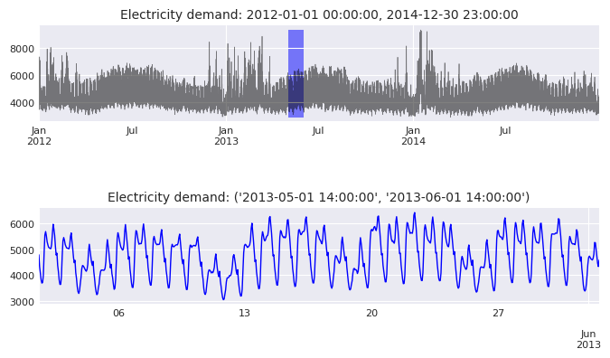

```python
# Zooming time series chart
# ==============================================================================
zoom = ('2013-05-01 14:00:00', '2013-06-01 14:00:00')
fig = plt.figure(figsize=(8, 4))
grid = plt.GridSpec(nrows=8, ncols=1, hspace=0.6, wspace=0)
main_ax = fig.add_subplot(grid[:3, :])
data.Demand.plot(ax=main_ax, c='black', alpha=0.5, linewidth=0.5)
min_y = min(data.Demand)
max_y = max(data.Demand)
main_ax.fill_between(zoom, min_y, max_y, facecolor='blue', alpha=0.5, zorder=0)
main_ax.set_title(f'Electricity demand: {data.index.min()}, {data.index.max()}', fontsize=10)
main_ax.set_xlabel('')
zoom_ax = fig.add_subplot(grid[5:, :])
data.loc[zoom[0]: zoom[1]].Demand.plot(ax=zoom_ax, color='blue', linewidth=1)
zoom_ax.set_title(f'Electricity demand: {zoom}', fontsize=10)
zoom_ax.set_xlabel('')
plt.subplots_adjust(hspace=1)
plt.show();
```

When the time series are zoomed in, a clear weekly seasonality can be seen, with higher consumption during the working week (Monday to Friday) and lower consumption at weekends. There is also a clear correlation between the consumption of one day and that of the previous day.

### Seasonality plots

Seasonal plots are a useful tool for identifying seasonal patterns and trends in a time series. They are created by averaging the values of each season over time and then plotting them against time.

**Annual, weekly and daily seasonality**

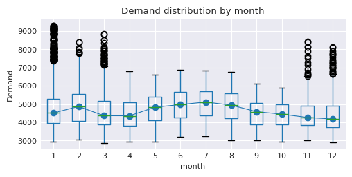

```python
# Demand distribution by month
# ==============================================================================
fig, ax = plt.subplots(figsize=(5.5, 2.5))
data['month'] = data.index.month
data.boxplot(column='Demand', by='month', ax=ax,)
data.groupby('month')['Demand'].median().plot(style='o-', linewidth=0.8, ax=ax)
ax.set_ylabel('Demand')
ax.set_title('Demand distribution by month')
fig.suptitle('')
plt.show();
```

It is observed that there is an annual seasonality, with higher (median) demand values in June, July, and August, and with high demand peaks in November, December, January, February, and March.

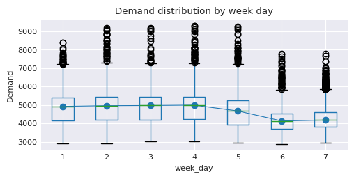

```python
# Demand distribution by week day
# ==============================================================================
fig, ax = plt.subplots(figsize=(5.5, 2.5))
data['week_day'] = data.index.day_of_week + 1
data.boxplot(column='Demand', by='week_day', ax=ax)
data.groupby('week_day')['Demand'].median().plot(style='o-', linewidth=0.8, ax=ax)
ax.set_ylabel('Demand')
ax.set_title('Demand distribution by week day')
fig.suptitle('')
plt.show();
```

Weekly seasonality shows lower demand values during the weekend.

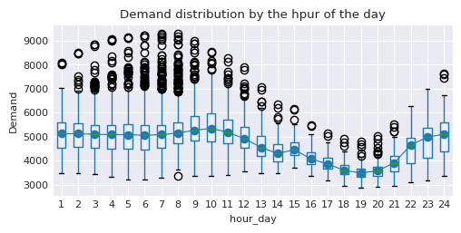

```python
# Demand distribution by the hour of the day
# ==============================================================================
fig, ax = plt.subplots(figsize=(5.5, 2.5))
data['hour_day'] = data.index.hour + 1
data.boxplot(column='Demand', by='hour_day', ax=ax)
data.groupby('hour_day')['Demand'].median().plot(style='o-', linewidth=0.8, ax=ax)
ax.set_ylabel('Demand')
ax.set_title('Demand distribution by the hpur of the day')
fig.suptitle('')
plt.show();
```

There is also a daily seasonality, with demand falling between 16:00 and 21:00 hours.

### Autocorrelation plots

Auto-correlation plots are a useful tool for identifying the order of an autoregressive model. The autocorrelation function (ACF) is a measure of the correlation between the time series and a lagged version of itself. The partial autocorrelation function (PACF) is a measure of the correlation between the time series and a lagged version of itself, controlling for the values of the time series at all shorter lags. These plots are useful for identifying the lags to be included in the autoregressive model.

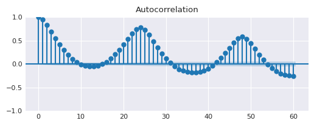

```python
# Autocorrelation plot
# ==============================================================================
fig, ax = plt.subplots(figsize=(6, 2))
plot_acf(data.Demand, ax=ax, lags=60)
plt.show()
```

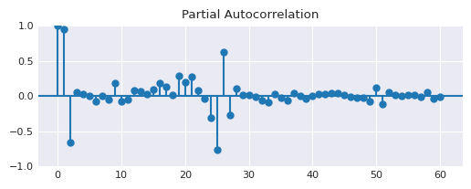

```python
# Partial autocorrelation plot
# ==============================================================================
fig, ax = plt.subplots(figsize=(6, 2))
plot_pacf(data.Demand, ax=ax, lags=60)
plt.show()
```

The autocorrelation plot demonstrates a strong correlation between demand in one hour and prior hours, as well as between demand in one hour and the corresponding hour in preceding days. This observed correlation suggests that autoregressive models may be effective in this scenario.

## Baseline

When faced with a forecasting problem, it is important to establish a baseline model. This is usually a very simple model that can be used as a reference to assess whether more complex models are worth implementing.

Skforecast allows you to easily create a baseline with its class [ForecasterEquivalentDate](https://skforecast.org/latest/user_guides/forecasting-baseline.html). This model, also known as Seasonal Naive Forecasting, simply returns the value observed in the same period of the previous season (e.g., the same working day from the previous week, the same hour from the previous day, etc.).

Based on the exploratory analysis performed, the baseline model will be the one that predicts each hour using the value of the same hour on the previous day.

**✎ Note**

In the following code cells, a baseline forecaster is trained and its predictive ability is evaluated using a backtesting process. If this concept is new to you, do not worry, it will be explained in detail throughout the document. For now, it is sufficient to know that the backtesting process consists of training the model with a certain amount of data and evaluating its predictive ability with the data that the model has not seen. The error metric will be used as a reference to evaluate the predictive ability of the more complex models that will be implemented later.

```python
# Create baseline: value of the same hour of the previous day
# ==============================================================================
forecaster = ForecasterEquivalentDate(
                 offset    = pd.DateOffset(days=1),
                 n_offsets = 1
             )

# Train forecaster
# ==============================================================================
forecaster.fit(y=data.loc[:end_validation, 'Demand'])
forecaster
```

```
========================
ForecasterEquivalentDate
========================
Offset: <DateOffset: days=1>
Number of offsets: 1
Aggregation function: mean
Window size: 24
Training range: [Timestamp('2012-01-01 00:00:00'), Timestamp('2014-11-30 23:00:00')]
Training index type: DatetimeIndex
Training index frequency: H
Creation date: 2024-05-05 14:30:51
Last fit date: 2024-05-05 14:30:51
Skforecast version: 0.12.0
Python version: 3.11.8
Forecaster id: None
```

```python
# Backtesting
# ==============================================================================
metric, predictions = backtesting_forecaster(
                          forecaster         = forecaster,
                          y                  = data['Demand'],
                          steps              = 24,
                          metric             = 'mean_absolute_error',
                          initial_train_size = len(data.loc[:end_validation]),
                          refit              = False,
                          n_jobs             = 'auto',
                          verbose            = False,
                          show_progress      = True
                      )

print(f"Backtest error (MAE): {metric}")
```

```
Backtest error (MAE): 308.3752715958334
```

## Recursive multi-step forecasting

A recursive autoregressive model [ForecasterAutoreg](https://joaquinamatrodrigo.github.io/skforecast/latest/user_guides/autoregresive-forecaster.html) is trained using a gradient boosting regressor [LGBMRegressor](https://lightgbm.readthedocs.io/en/latest/pythonapi/lightgbm.LGBMRegressor.html) as the base regressor. A time window of 24 hours (24 lags) is used to predict the next hour's demand. This means that the demand values of the previous 24 hours are used as predictors. The hyperparameters of the underlying regressor are left at their default values.

```python
# Create forecaster
# ==============================================================================
forecaster = ForecasterAutoreg(
                 regressor = LGBMRegressor(random_state=15926, verbose=-1),
                 lags      = 24
             )

# Train forecaster
# ==============================================================================
forecaster.fit(y=data.loc[:end_validation, 'Demand'])
forecaster
```

```
=================
ForecasterAutoreg
=================
Regressor: LGBMRegressor(random_state=15926, verbose=-1)
Lags: [ 1  2  3  4  5  6  7  8  9 10 11 12 13 14 15 16 17 18 19 20 21 22 23 24]
Transformer for y: None
Transformer for exog: None
Window size: 24
Weight function included: False
Differentiation order: None
Exogenous included: False
Type of exogenous variable: None
Exogenous variables names: None
Training range: [Timestamp('2012-01-01 00:00:00'), Timestamp('2014-11-30 23:00:00')]
Training index type: DatetimeIndex
Training index frequency: H
Regressor parameters: {'boosting_type': 'gbdt', 'class_weight': None, 'colsample_bytree': 1.0, 'importance_type': 'split', 'learning_rate': 0.1, 'max_depth': -1, 'min_child_samples': 20, 'min_child_weight': 0.001, 'min_split_gain': 0.0, 'n_estimators': 100, 'n_jobs': None, 'num_leaves': 31, 'objecti…
fit_kwargs: {}
Creation date: 2024-05-05 14:30:52
Last fit date: 2024-05-05 14:30:52
Skforecast version: 0.12.0
Python version: 3.11.8
Forecaster id: None
```

### Backtesting

To obtain a robust estimate of the model's predictive ability, a backtesting process is performed. The backtesting process consists of generating a forecast for each observation in the test set, following the same procedure as would be done in production, and then comparing the predicted value to the actual value.

The backtesting process is applied using the `backtesting_forecaster()` function. For this use case, the simulation is carried out as follows: the model is trained with data from 2012-01-01 00:00 to 2014-11-30 23:00, and then it predicts the next 24 hours every day at 23:59. The error metric used is the Mean Absolute Error (MAE).

**✎ Note**

Since **skforecast 0.9.0**, all backtesting and grid search functions have been extended to include the `n_jobs` argument, allowing multi-process parallelization for improved performance. This applies to all functions of the different `model_selection` modules. The benefits of parallelization depend on several factors, including the regressor used, the number of fits to be performed, and the volume of data involved. When the `n_jobs` parameter is set to `'auto'`, the level of parallelization is automatically selected based on heuristic rules that aim to choose the best option for each scenario. For more information, see the [backtesting](https://skforecast.org/latest/user_guides/backtesting.html) section of the documentation.

```python
# Backtesting
# ==============================================================================
metric, predictions = backtesting_forecaster(
                          forecaster         = forecaster,
                          y                  = data['Demand'],
                          steps              = 24,
                          metric             = 'mean_absolute_error',
                          initial_train_size = len(data.loc[:end_validation]),
                          refit              = False,
                          n_jobs             = 'auto',
                          verbose            = True,
                          show_progress      = True
                      )
```

```
Information of backtesting process
----------------------------------
Number of observations used for initial training: 25560
Number of observations used for backtesting: 720
    Number of folds: 30
    Number of steps per fold: 24
    Number of steps to exclude from the end of each train set before test (gap): 0

Fold: 0
    Training:   2012-01-01 00:00:00 -- 2014-11-30 23:00:00  (n=25560)
    Validation: 2014-12-01 00:00:00 -- 2014-12-01 23:00:00  (n=24)
Fold: 1
    Training:   2012-01-01 00:00:00 -- 2014-11-30 23:00:00  (n=25560)
    Validation: 2014-12-02 00:00:00 -- 2014-12-02 23:00:00  (n=24)
Fold: 2
    Training:   2012-01-01 00:00:00 -- 2014-11-30 23:00:00  (n=25560)
    Validation: 2014-12-03 00:00:00 -- 2014-12-03 23:00:00  (n=24)
Fold: 3
    Training:   2012-01-01 00:00:00 -- 2014-11-30 23:00:00  (n=25560)
    Validation: 2014-12-04 00:00:00 -- 2014-12-04 23:00:00  (n=24)
Fold: 4
    Training:   2012-01-01 00:00:00 -- 2014-11-30 23:00:00  (n=25560)
    Validation: 2014-12-05 00:00:00 -- 2014-12-05 23:00:00  (n=24)
Fold: 5
    Training:   2012-01-01 00:00:00 -- 2014-11-30 23:00:00  (n=25560)
    Validation: 2014-12-06 00:00:00 -- 2014-12-06 23:00:00  (n=24)
Fold: 6
    Training:   2012-01-01 00:00:00 -- 2014-11-30 23:00:00  (n=25560)
    Validation: 2014-12-07 00:00:00 -- 2014-12-07 23:00:00  (n=24)
Fold: 7
    Training:   2012-01-01 00:00:00 -- 2014-11-30 23:00:00  (n=25560)
    Validation: 2014-12-08 00:00:00 -- 2014-12-08 23:00:00  (n=24)
Fold: 8
    Training:   2012-01-01 00:00:00 -- 2014-11-30 23:00:00  (n=25560)
    Validation: 2014-12-09 00:00:00 -- 2014-12-09 23:00:00  (n=24)
Fold: 9
    Training:   2012-01-01 00:00:00 -- 2014-11-30 23:00:00  (n=25560)
    Validation: 2014-12-10 00:00:00 -- 2014-12-10 23:00:00  (n=24)
Fold: 10
    Training:   2012-01-01 00:00:00 -- 2014-11-30 23:00:00  (n=25560)
```

[output cut: 43 more lines]

```
Fold: 25
    Training:   2012-01-01 00:00:00 -- 2014-11-30 23:00:00  (n=25560)
    Validation: 2014-12-26 00:00:00 -- 2014-12-26 23:00:00  (n=24)
Fold: 26
    Training:   2012-01-01 00:00:00 -- 2014-11-30 23:00:00  (n=25560)
    Validation: 2014-12-27 00:00:00 -- 2014-12-27 23:00:00  (n=24)
Fold: 27
    Training:   2012-01-01 00:00:00 -- 2014-11-30 23:00:00  (n=25560)
    Validation: 2014-12-28 00:00:00 -- 2014-12-28 23:00:00  (n=24)
Fold: 28
    Training:   2012-01-01 00:00:00 -- 2014-11-30 23:00:00  (n=25560)
    Validation: 2014-12-29 00:00:00 -- 2014-12-29 23:00:00  (n=24)
Fold: 29
    Training:   2012-01-01 00:00:00 -- 2014-11-30 23:00:00  (n=25560)
    Validation: 2014-12-30 00:00:00 -- 2014-12-30 23:00:00  (n=24)
```

```python
# Plot predictions vs real value
# ======================================================================================
fig = go.Figure()
trace1 = go.Scatter(x=data_test.index, y=data_test['Demand'], name="test", mode="lines")
trace2 = go.Scatter(x=predictions.index, y=predictions['pred'], name="prediction", mode="lines")
fig.add_trace(trace1)
fig.add_trace(trace2)
fig.update_layout(
    title="Real value vs predicted in test data",
    xaxis_title="Date time",
    yaxis_title="Demand",
    width=800,
    height=400,
    margin=dict(l=20, r=20, t=35, b=20),
    legend=dict(
        orientation="h",
        yanchor="top",
        y=1.1,
        xanchor="left",
        x=0.001
    )
)
fig.show()
```

[interactive chart not shown]

```python
# Backtesting error
# ==============================================================================
print(f'Backtest error (MAE): {metric}')
```

```
Backtest error (MAE): 236.38849515592196
```

The autoregressive model achieves a lower MAE than the baseline model. This means that the autoregressive model is able to predict the next day's electricity demand more accurately than the baseline model.

### Hyperparameter tuning

The trained `ForecasterAutoreg` object used the first 24 lags and a `LGMBRegressor` model with the default hyperparameters. However, there is no reason why these values are the most appropriate. To find the best hyperparameters, a [Bayesian Search](https://skforecast.org/latest/user_guides/hyperparameter-tuning-and-lags-selection#bayesian-search) is performed using the `bayesian_search_forecaster()` function. The search is carried out using the same backtesting process as before, but each time, the model is trained with different combinations of hyperparameters and lags. It is important to note that the hiperparameter search must be done using the validation set, so the test data is never used.

```python
# Hyperparameters search
# ==============================================================================
forecaster = ForecasterAutoreg(
                 regressor = LGBMRegressor(random_state=15926, verbose=-1),
                 lags      = 24, # This value will be replaced in the grid search
             )

# Lags used as predictors
lags_grid = [24, (1, 2, 3, 23, 24, 25, 47, 48, 49)]

# Regressor hyperparameters search space
def search_space(trial):
    search_space  = {
        'n_estimators'  : trial.suggest_int('n_estimators', 600, 1200, step=100),
        'max_depth'     : trial.suggest_int('max_depth', 3, 10, step=1),
        'learning_rate' : trial.suggest_float('learning_rate', 0.01, 0.5),
        'reg_alpha'     : trial.suggest_float('reg_alpha', 0, 1, step=0.1),
        'reg_lambda'    : trial.suggest_float('reg_lambda', 0, 1, step=0.1),
        'lags'          : trial.suggest_categorical('lags', lags_grid)
    }
    return search_space

results_search, frozen_trial = bayesian_search_forecaster(
                                   forecaster         = forecaster,
                                   y                  = data.loc[:end_validation, 'Demand'],
                                   steps              = 24,
                                   metric             = 'mean_absolute_error',
                                   search_space       = search_space,
                                   initial_train_size = len(data[:end_train]),
                                   refit              = False,
                                   n_trials           = 20, # Increase for more exhaustive search
                                   random_state       = 123,
                                   return_best        = True,
                                   n_jobs             = 'auto',
                                   verbose            = False,
                                   show_progress      = True
                               )
```

```
`Forecaster` refitted using the best-found lags and parameters, and the whole data set:
  Lags: [ 1  2  3  4  5  6  7  8  9 10 11 12 13 14 15 16 17 18 19 20 21 22 23 24]
  Parameters: {'n_estimators': 800, 'max_depth': 8, 'learning_rate': 0.05513142057308684, 'reg_alpha': 0.4, 'reg_lambda': 0.4}
  Backtesting metric: 237.8559671096808
```

```python
# Search results
# ==============================================================================
results_search.head(10)
```

|  | lags | params | mean_absolute_error | n_estimators | max_depth | learning_rate | reg_alpha | reg_lambda |
| --- | --- | --- | --- | --- | --- | --- | --- | --- |
| 4 | [1, 2, 3, 4, 5, 6, 7, 8, 9, 10, 11, 12, 13, 14... | {'n_estimators': 800, 'max_depth': 8, 'learnin... | 237.855967 | 800.0 | 8.0 | 0.055131 | 0.4 | 0.4 |
| 19 | [1, 2, 3, 4, 5, 6, 7, 8, 9, 10, 11, 12, 13, 14... | {'n_estimators': 700, 'max_depth': 9, 'learnin... | 238.297293 | 700.0 | 9.0 | 0.059282 | 0.5 | 0.1 |
| 17 | [1, 2, 3, 4, 5, 6, 7, 8, 9, 10, 11, 12, 13, 14... | {'n_estimators': 1100, 'max_depth': 9, 'learni... | 238.399788 | 1100.0 | 9.0 | 0.165919 | 0.5 | 0.7 |
| 1 | [1, 2, 3, 4, 5, 6, 7, 8, 9, 10, 11, 12, 13, 14... | {'n_estimators': 1000, 'max_depth': 6, 'learni... | 239.635156 | 1000.0 | 6.0 | 0.202138 | 0.3 | 0.8 |
| 16 | [1, 2, 3, 4, 5, 6, 7, 8, 9, 10, 11, 12, 13, 14... | {'n_estimators': 1200, 'max_depth': 5, 'learni... | 239.929035 | 1200.0 | 5.0 | 0.085786 | 0.3 | 0.3 |
| 11 | [1, 2, 3, 4, 5, 6, 7, 8, 9, 10, 11, 12, 13, 14... | {'n_estimators': 1200, 'max_depth': 4, 'learni... | 242.633076 | 1200.0 | 4.0 | 0.185077 | 0.3 | 1.0 |
| 14 | [1, 2, 3, 4, 5, 6, 7, 8, 9, 10, 11, 12, 13, 14... | {'n_estimators': 700, 'max_depth': 5, 'learnin... | 244.464263 | 700.0 | 5.0 | 0.145675 | 0.0 | 0.3 |
| 12 | [1, 2, 3, 4, 5, 6, 7, 8, 9, 10, 11, 12, 13, 14... | {'n_estimators': 600, 'max_depth': 7, 'learnin... | 248.248482 | 600.0 | 7.0 | 0.216223 | 0.1 | 1.0 |
| 15 | [1, 2, 3, 4, 5, 6, 7, 8, 9, 10, 11, 12, 13, 14... | {'n_estimators': 900, 'max_depth': 10, 'learni... | 248.687497 | 900.0 | 10.0 | 0.266508 | 0.4 | 0.8 |
| 10 | [1, 2, 3, 4, 5, 6, 7, 8, 9, 10, 11, 12, 13, 14... | {'n_estimators': 600, 'max_depth': 10, 'learni... | 250.548354 | 600.0 | 10.0 | 0.033252 | 0.4 | 0.0 |

Since `return_best` has been set to `True`, the forecaster object is automatically updated with the best configuration found and trained on the entire dataset. This final model can then be used for future predictions on new data.

```python
# Best model
# ==============================================================================
forecaster
```

```
=================
ForecasterAutoreg
=================
Regressor: LGBMRegressor(learning_rate=0.05513142057308684, max_depth=8, n_estimators=800,
              random_state=15926, reg_alpha=0.4, reg_lambda=0.4, verbose=-1)
Lags: [ 1  2  3  4  5  6  7  8  9 10 11 12 13 14 15 16 17 18 19 20 21 22 23 24]
Transformer for y: None
Transformer for exog: None
Window size: 24
Weight function included: False
Differentiation order: None
Exogenous included: False
Type of exogenous variable: None
Exogenous variables names: None
Training range: [Timestamp('2012-01-01 00:00:00'), Timestamp('2014-11-30 23:00:00')]
Training index type: DatetimeIndex
Training index frequency: H
Regressor parameters: {'boosting_type': 'gbdt', 'class_weight': None, 'colsample_bytree': 1.0, 'importance_type': 'split', 'learning_rate': 0.05513142057308684, 'max_depth': 8, 'min_child_samples': 20, 'min_child_weight': 0.001, 'min_split_gain': 0.0, 'n_estimators': 800, 'n_jobs': None, 'num_leaves…
fit_kwargs: {}
Creation date: 2024-05-05 14:30:54
Last fit date: 2024-05-05 14:34:14
Skforecast version: 0.12.0
Python version: 3.11.8
Forecaster id: None
```

### Backtesting on test data

Once the best combination of hyperparameters has been identified **using the validation data**, the predictive capacity of the model is evaluated when applied to the test set. It is highly recommended to review the documentation for the [backtesting_forecaster()](https://skforecast.org/latest/user_guides/backtesting.html) function to gain a better understanding of its capabilities. This will help to utilize its full potential to analyze the predictive ability of the model.

```python
# Backtest final model on test data
# ==============================================================================
metric, predictions = backtesting_forecaster(
                          forecaster         = forecaster,
                          y                  = data['Demand'],
                          steps              = 24,
                          metric             = 'mean_absolute_error',
                          initial_train_size = len(data[:end_validation]),
                          refit              = False,
                          n_jobs             = 'auto',
                          verbose            = False, # Change to True to see detailed information
                          show_progress      = True
                      )

print(f"Backtest error: {metric:.2f}")
predictions.head()
```

```
Backtest error: 198.26
```

|  | pred |
| --- | --- |
| 2014-12-01 00:00:00 | 5613.701110 |
| 2014-12-01 01:00:00 | 5597.650623 |
| 2014-12-01 02:00:00 | 5583.070192 |
| 2014-12-01 03:00:00 | 5607.766871 |
| 2014-12-01 04:00:00 | 5602.253078 |

After optimization of lags and hyperparameters, the prediction error was notably reduced.

## Forecasting with exogenous variables

So far, only lagged values of the time series have been used as predictors. However, it is possible to include other variables as predictors. These variables are known as exogenous variables (features) and their use can improve the predictive capacity of the model. A very important point to keep in mind is that the values of the exogenous variables must be known at the time of prediction.

Common examples of exogenous variables are those derived from the calendar, such as the day of the week, month, year, or holidays. Weather variables such as temperature, humidity, and wind also fall into this category, as do economic variables such as inflation and interest rates.

**⚠ Warning**

Exogenous variables must be known at the time of the forecast. For example, if temperature is used as an exogenous variable, the temperature value for the next hour must be known at the time of the forecast. If the temperature value is not known, the forecast will not be possible.  
Weather variables should be used with caution. When the model is deployed into production, future weather conditions are not known, but are predictions made by meteorological services. Because they are predictions, they introduce errors into the forecasting model. As a result, the model's predictions are likely to get worse. One way to anticipate this problem, and to know (not avoid) the expected performance of the model, is to use the weather forecasts available at the time the model is trained, rather than the recorded conditions.

### Exogenous variables

Next, exogenous variables are created based on calendar information, sunrise and sunset times, temperature, and holidays. These new variables are then added to the training, validation and test sets, and used as predictors in the autoregressive model.

```python
# Calendar features
# ==============================================================================
calendar_features = pd.DataFrame(index=data.index)
calendar_features['month'] = calendar_features.index.month
calendar_features['week_of_year'] = calendar_features.index.isocalendar().week
calendar_features['week_day'] = calendar_features.index.day_of_week + 1
calendar_features['hour_day'] = calendar_features.index.hour + 1

# Sunlight features
# ==============================================================================
location = LocationInfo(
    "Melbourne",
    "Australia",
    latitude=-37.8,
    longitude=144.95,
    timezone='Australia/Melbourne'
)
sunrise_hour = [
    sun(location.observer, date=date, tzinfo=location.timezone)['sunrise'].hour
    for date in data.index
]
sunset_hour = [
    sun(location.observer, date=date, tzinfo=location.timezone)['sunset'].hour
    for date in data.index
]
sun_light_features = pd.DataFrame({
                         'sunrise_hour': sunrise_hour,
                         'sunset_hour': sunset_hour},
                         index = data.index
                     )
sun_light_features['daylight_hours'] = (
    sun_light_features['sunset_hour'] - sun_light_features['sunrise_hour']
)
sun_light_features['is_daylight'] = np.where(
                                        (data.index.hour >= sun_light_features['sunrise_hour']) & \
                                        (data.index.hour < sun_light_features['sunset_hour']),
                                        1,
                                        0
                                    )

# Holiday features
# ==============================================================================
holiday_features = data[['Holiday']].astype(int)
holiday_features['holiday_previous_day'] = holiday_features['Holiday'].shift(24)
holiday_features['holiday_next_day'] = holiday_features['Holiday'].shift(-24)

# Temperature features
# ==============================================================================
temp_features = data[['Temperature']].copy()
temp_features['temp_roll_mean_1_day'] = temp_features['Temperature'].rolling(24, closed='left').mean()
temp_features['temp_roll_mean_7_day'] = temp_features['Temperature'].rolling(24*7, closed='left').mean()
temp_features['temp_roll_max_1_day'] = temp_features['Temperature'].rolling(24, closed='left').max()
temp_features['temp_roll_min_1_day'] = temp_features['Temperature'].rolling(24, closed='left').min()
temp_features['temp_roll_max_7_day'] = temp_features['Temperature'].rolling(24*7, closed='left').max()
temp_features['temp_roll_min_7_day'] = temp_features['Temperature'].rolling(24*7, closed='left').min()


# Merge all exogenous variables
# ==============================================================================
exogenous_features = pd.concat([
                         calendar_features,
                         sun_light_features,
                         temp_features,
                         holiday_features
                     ], axis=1)

exogenous_features.head(4)
```

| Time | month | week_of_year | week_day | hour_day | sunrise_hour | sunset_hour | daylight_hours | is_daylight | Temperature | temp_roll_mean_1_day | temp_roll_mean_7_day | temp_roll_max_1_day | temp_roll_min_1_day | temp_roll_max_7_day | temp_roll_min_7_day | Holiday | holiday_previous_day | holiday_next_day |
| --- | --- | --- | --- | --- | --- | --- | --- | --- | --- | --- | --- | --- | --- | --- | --- | --- | --- | --- |
| 2012-01-01 00:00:00 | 1 | 52 | 7 | 1 | 6 | 20 | 14 | 0 | 27.000 | NaN | NaN | NaN | NaN | NaN | NaN | 1 | NaN | 1.0 |
| 2012-01-01 01:00:00 | 1 | 52 | 7 | 2 | 6 | 20 | 14 | 0 | 29.650 | NaN | NaN | NaN | NaN | NaN | NaN | 1 | NaN | 1.0 |
| 2012-01-01 02:00:00 | 1 | 52 | 7 | 3 | 6 | 20 | 14 | 0 | 31.650 | NaN | NaN | NaN | NaN | NaN | NaN | 1 | NaN | 1.0 |
| 2012-01-01 03:00:00 | 1 | 52 | 7 | 4 | 6 | 20 | 14 | 0 | 32.675 | NaN | NaN | NaN | NaN | NaN | NaN | 1 | NaN | 1.0 |

Certain aspects of the calendar, such as hours or days, are cyclical. For example, the hour-day cycle ranges from 0 to 23 hours. Although interpreted as a continuous variable, the hour 23:00 is only one hour away from 00:00. The same is true for the month-year cycle, since December is only one month away from January. The use of trigonometric functions such as sine and cosine transformations makes it possible to represent cyclic patterns and avoid inconsistencies in data representation. This approach is known as cyclic encoding and can significantly improve the predictive ability of models.

```python
# Cliclical encoding of calendar and sunlight features
# ==============================================================================
def cyclical_encoding(data: pd.Series, cycle_length: int) -> pd.DataFrame:
    """
    Encode a cyclical feature with two new features sine and cosine.
    The minimum value of the feature is assumed to be 0. The maximum value
    of the feature is passed as an argument.

    Parameters
    ----------
    data : pd.Series
        Series with the feature to encode.
    cycle_length : int
        The length of the cycle. For example, 12 for months, 24 for hours, etc.
        This value is used to calculate the angle of the sin and cos.

    Returns
    -------
    result : pd.DataFrame
        Dataframe with the two new features sin and cos.

    """

    sin = np.sin(2 * np.pi * data/cycle_length)
    cos = np.cos(2 * np.pi * data/cycle_length)
    result =  pd.DataFrame({
                  f"{data.name}_sin": sin,
                  f"{data.name}_cos": cos
              })

    return result


month_encoded = cyclical_encoding(exogenous_features['month'], cycle_length=12)
week_of_year_encoded = cyclical_encoding(exogenous_features['week_of_year'], cycle_length=52)
week_day_encoded = cyclical_encoding(exogenous_features['week_day'], cycle_length=7)
hour_day_encoded = cyclical_encoding(exogenous_features['hour_day'], cycle_length=24)
sunrise_hour_encoded = cyclical_encoding(exogenous_features['sunrise_hour'], cycle_length=24)
sunset_hour_encoded = cyclical_encoding(exogenous_features['sunset_hour'], cycle_length=24)

cyclical_features = pd.concat([
                        month_encoded,
                        week_of_year_encoded,
                        week_day_encoded,
                        hour_day_encoded,
                        sunrise_hour_encoded,
                        sunset_hour_encoded
                    ], axis=1)

exogenous_features = pd.concat([exogenous_features, cyclical_features], axis=1)
exogenous_features.head(3)
```

| Time | month | week_of_year | week_day | hour_day | sunrise_hour | sunset_hour | daylight_hours | is_daylight | Temperature | temp_roll_mean_1_day | ... | week_of_year_sin | week_of_year_cos | week_day_sin | week_day_cos | hour_day_sin | hour_day_cos | sunrise_hour_sin | sunrise_hour_cos | sunset_hour_sin | sunset_hour_cos |
| --- | --- | --- | --- | --- | --- | --- | --- | --- | --- | --- | --- | --- | --- | --- | --- | --- | --- | --- | --- | --- | --- |
| 2012-01-01 00:00:00 | 1 | 52 | 7 | 1 | 6 | 20 | 14 | 0 | 27.00 | NaN | ... | 0.0 | 1.0 | -2.449294e-16 | 1.0 | 0.258819 | 0.965926 | 1.0 | 6.123234e-17 | -0.866025 | 0.5 |
| 2012-01-01 01:00:00 | 1 | 52 | 7 | 2 | 6 | 20 | 14 | 0 | 29.65 | NaN | ... | 0.0 | 1.0 | -2.449294e-16 | 1.0 | 0.500000 | 0.866025 | 1.0 | 6.123234e-17 | -0.866025 | 0.5 |
| 2012-01-01 02:00:00 | 1 | 52 | 7 | 3 | 6 | 20 | 14 | 0 | 31.65 | NaN | ... | 0.0 | 1.0 | -2.449294e-16 | 1.0 | 0.707107 | 0.707107 | 1.0 | 6.123234e-17 | -0.866025 | 0.5 |

3 rows × 30 columns

**✎ Note**

For illustrative purposes, calendar features and their cyclic encoding have been done manually. However, for a more efficient and automated approach, it is recommended to use the transformers [DatetimeFeatures](https://feature-engine.trainindata.com/en/latest/api_doc/datetime/DatetimeFeatures.html) and [CyclicalFeatures](https://feature-engine.trainindata.com/en/latest/user_guide/creation/CyclicalFeatures.html) available in *Feature-engine* library, and pass them directly to the `transformer_exog` argument of the forecaster.

In many cases, exogenous variables are not isolated. Rather, their effect on the target variable depends on the value of other variables. For example, the effect of temperature on electricity demand depends on the time of day. The interaction between the exogenous variables can be captured by new variables that are obtained by multiplying existing variables together. This interactions are easily obtained with the [PolynomialFeatures](https://scikit-learn.org/stable/modules/generated/sklearn.preprocessing.PolynomialFeatures.html) class from scikit-learn.

```python
# Interaction between exogenous variables
# ==============================================================================
transformer_poly = PolynomialFeatures(
                       degree           = 2,
                       interaction_only = True,
                       include_bias     = False
                   ).set_output(transform="pandas")

poly_cols = [
    'month_sin',
    'month_cos',
    'week_of_year_sin',
    'week_of_year_cos',
    'week_day_sin',
    'week_day_cos',
    'hour_day_sin',
    'hour_day_cos',
    'sunrise_hour_sin',
    'sunrise_hour_cos',
    'sunset_hour_sin',
    'sunset_hour_cos',
    'daylight_hours',
    'is_daylight',
    'holiday_previous_day',
    'holiday_next_day',
    'temp_roll_mean_1_day',
    'temp_roll_mean_7_day',
    'temp_roll_max_1_day',
    'temp_roll_min_1_day',
    'temp_roll_max_7_day',
    'temp_roll_min_7_day',
    'Temperature',
    'Holiday'
]

poly_features = transformer_poly.fit_transform(exogenous_features[poly_cols].dropna())
poly_features = poly_features.drop(columns=poly_cols)
poly_features.columns = [f"poly_{col}" for col in poly_features.columns]
poly_features.columns = poly_features.columns.str.replace(" ", "__")
exogenous_features = pd.concat([exogenous_features, poly_features], axis=1)
exogenous_features.head(4)
```

| Time | month | week_of_year | week_day | hour_day | sunrise_hour | sunset_hour | daylight_hours | is_daylight | Temperature | temp_roll_mean_1_day | ... | poly_temp_roll_min_1_day__temp_roll_max_7_day | poly_temp_roll_min_1_day__temp_roll_min_7_day | poly_temp_roll_min_1_day__Temperature | poly_temp_roll_min_1_day__Holiday | poly_temp_roll_max_7_day__temp_roll_min_7_day | poly_temp_roll_max_7_day__Temperature | poly_temp_roll_max_7_day__Holiday | poly_temp_roll_min_7_day__Temperature | poly_temp_roll_min_7_day__Holiday | poly_Temperature__Holiday |
| --- | --- | --- | --- | --- | --- | --- | --- | --- | --- | --- | --- | --- | --- | --- | --- | --- | --- | --- | --- | --- | --- |
| 2012-01-01 00:00:00 | 1 | 52 | 7 | 1 | 6 | 20 | 14 | 0 | 27.000 | NaN | ... | NaN | NaN | NaN | NaN | NaN | NaN | NaN | NaN | NaN | NaN |
| 2012-01-01 01:00:00 | 1 | 52 | 7 | 2 | 6 | 20 | 14 | 0 | 29.650 | NaN | ... | NaN | NaN | NaN | NaN | NaN | NaN | NaN | NaN | NaN | NaN |
| 2012-01-01 02:00:00 | 1 | 52 | 7 | 3 | 6 | 20 | 14 | 0 | 31.650 | NaN | ... | NaN | NaN | NaN | NaN | NaN | NaN | NaN | NaN | NaN | NaN |
| 2012-01-01 03:00:00 | 1 | 52 | 7 | 4 | 6 | 20 | 14 | 0 | 32.675 | NaN | ... | NaN | NaN | NaN | NaN | NaN | NaN | NaN | NaN | NaN | NaN |

4 rows × 306 columns

```python
# Select exogenous variables to be included in the model
# ==============================================================================
exog_features = []

# Columns that ends with _sin or _cos are selected
exog_features.extend(exogenous_features.filter(regex='_sin$|_cos$').columns.tolist())

# Columns that start with temp_ are selected
exog_features.extend(exogenous_features.filter(regex='^temp_.*').columns.tolist())

# Columns that start with holiday_ are selected
exog_features.extend(exogenous_features.filter(regex='^holiday_.*').columns.tolist())

# Include original features
exog_features.extend(['Temperature', 'Holiday'])
```

```python
# Merge target and exogenous variables in the same DataFrame
# ==============================================================================
data = data[['Demand']].merge(
           exogenous_features[exog_features],
           left_index=True,
           right_index=True,
           how='left'
       )

# Due to the creation of moving averages, there are missing values at the beginning
# of the series. Due to holiday_next_day there are missing values at the end.
data = data.dropna()
data = data.astype('float32')

# Split data into train-val-test
data_train = data.loc[: end_train, :].copy()
data_val   = data.loc[end_train:end_validation, :].copy()
data_test  = data.loc[end_validation:, :].copy()
```

The hyperparameters and lags identified as optimal in the previous section are again used to train the model, but this time, the exogenous variables are also included as predictors.

```python
# Create forecaster
# ==============================================================================
params = {
    'n_estimators': 800,
    'max_depth': 8,
    'learning_rate': 0.0551314,
    'reg_alpha': 0.4,
    'reg_lambda': 0.4,
    'random_state': 15926,
    'verbose': -1
}
forecaster = ForecasterAutoreg(
                 regressor = LGBMRegressor(**params),
                 lags      = 24
             )
```

```python
# Backtesting model
# ==============================================================================
metric, predictions = backtesting_forecaster(
                          forecaster         = forecaster,
                          y                  = data['Demand'],
                          exog               = data[exog_features],
                          steps              = 24,
                          metric             = 'mean_absolute_error',
                          initial_train_size = len(data[:end_validation]),
                          refit              = False,
                          n_jobs             = 'auto',
                          verbose            = False,
                          show_progress      = True
                      )

print(f"Backtest error: {metric:.2f}")
predictions.head()
```

```
Backtest error: 129.80
```

|  | pred |
| --- | --- |
| 2014-12-01 00:00:00 | 5561.629953 |
| 2014-12-01 01:00:00 | 5501.132966 |
| 2014-12-01 02:00:00 | 5453.086811 |
| 2014-12-01 03:00:00 | 5474.376494 |
| 2014-12-01 04:00:00 | 5530.322188 |

The inclusion of exogenous variables as predictors further improves the predictive capacity of the model.

## Probabilistic forecasting: Prediction intervals

A prediction interval defines the interval within which the true value of the target variable can be expected to be found with a given probability. Rob J Hyndman and George Athanasopoulos, in their book *Forecasting: Principles and Practice*, list [multiple ways to estimate prediction intervals](https://otexts.com/fpp2/prediction-intervals.html), most of which require that the residuals (errors) of the model to be normally distributed. If this cannot be assumed, one can resort to bootstrapping, which requires only that the residuals be uncorrelated. This is one of the methods available in skforecast. A more detailed explanation of prediction intervals can be found in the [Probabilistic forecasting: prediction intervals and prediction distribution](https://joaquinamatrodrigo.github.io/skforecast/latest/user_guides/probabilistic-forecasting.html) user guide.

The following code shows how to generate prediction intervals for the autoregressive model. The `prediction_interval()` function is used to generate the prediction intervals for each predicted step. Then, the `backtesting_forecaster()` function is used to generate the prediction intervals for the entire test set. The `interval` argument is used to specify the desired coverage probability of the prediction intervals. In this case, `interval` is set to `[10, 90]`, which means that the prediction intervals are calculated for the 10th and 90th percentiles, resulting in a theoretical coverage probability of 80%. The `n_boot` argument is used to specify the number of bootstrap samples to be used in estimating the prediction intervals. The larger the number of samples, the more accurate the prediction intervals will be, but the longer the calculation will take.

```python
# Create and train forecaster
# ==============================================================================
forecaster = ForecasterAutoreg(
                 regressor = LGBMRegressor(**params),
                 lags      = 24
             )
forecaster.fit(
    y    = data.loc[:end_train, 'Demand'],
    exog = data.loc[:end_train, exog_features]
)
```

```python
# Predict intervals
# ==============================================================================
# Since the model has been trained with exogenous variables, they must be provided
# for the prediction.
predictions = forecaster.predict_interval(
                  exog     = data.loc[end_train:, exog_features],
                  steps    = 24,
                  interval = [10, 90],
              )
predictions.head()
```

|  | pred | lower_bound | upper_bound |
| --- | --- | --- | --- |
| 2014-01-01 00:00:00 | 3632.907595 | 3597.005697 | 3666.728409 |
| 2014-01-01 01:00:00 | 3779.814713 | 3730.780320 | 3813.333882 |
| 2014-01-01 02:00:00 | 3864.840701 | 3816.042311 | 3913.918539 |
| 2014-01-01 03:00:00 | 3931.732495 | 3854.539271 | 3985.687516 |
| 2014-01-01 04:00:00 | 3981.538258 | 3910.052319 | 4043.020729 |

By default, intervals are calculated using in-sample residuals (residuals from the training set). However, this can result in intervals that are too narrow (overly optimistic). To avoid this, the `set_out_sample_residuals()` method is used to specify out-sample residuals computed with a validation set through backtesting.

If the predicted values are passed to `set_out_sample_residuals()` in addition to the residuals, then the residuals used in the bootstrapping process can be conditioned on the range of values of the predictions. This can help to improve the coverage of the estimated intervals while keeping them as narrow as possible.

```python
# Backtesting on validation data to obtain out-sample residuals
# ==============================================================================
_, predictions_val = backtesting_forecaster(
                         forecaster         = forecaster,
                         y                  = data.loc[:end_validation, 'Demand'], # Train + Validation
                         exog               = data.loc[:end_validation, exog_features],
                         steps              = 24,
                         metric             = 'mean_absolute_error',
                         initial_train_size = len(data.loc[:end_train]),
                         refit              = False,
                         n_jobs             = 'auto',
                         verbose            = False,
                         show_progress      = True
                     )
residuals = data.loc[predictions_val.index, 'Demand'] - predictions_val['pred']
residuals = residuals.dropna()
```

```python
# Out-sample residuals distribution
# ==============================================================================
print(pd.Series(np.where(residuals < 0, 'negative', 'positive')).value_counts())
fig, ax = plt.subplots(figsize=(8, 6))
_ = plot_residuals(residuals=residuals, fig=fig)
fig.tight_layout()
```

[output not shown]

```python
# Store out-sample residuals in the forecaster
# ==============================================================================
forecaster.set_out_sample_residuals(
    residuals = residuals,
    y_pred    = data.loc[predictions_val.index, 'Demand']
)
```

Then, backtest in the test set using the out-of-sample residuals by setting the `in_sample_residuals` argument to `False`.

```python
# Backtesting with prediction intervals in test data using out-sample residuals
# ==============================================================================
metric, predictions = backtesting_forecaster(
                          forecaster          = forecaster,
                          y                   = data['Demand'], # Full dataset
                          exog                = data[exog_features],
                          steps               = 24,
                          metric              = 'mean_absolute_error',
                          initial_train_size  = len(data.loc[:end_validation]),
                          refit               = False,
                          interval            = [10, 90],
                          n_boot              = 250,
                          in_sample_residuals = False, # Use out-sample residuals
                          binned_residuals    = True, # Residuals conditioned on predicted values
                          n_jobs              = 'auto',
                          verbose             = False,
                          show_progress       = True
                      )
predictions.head(5)
```

|  | pred | lower_bound | upper_bound |
| --- | --- | --- | --- |
| 2014-12-01 00:00:00 | 5561.629953 | 5377.777405 | 5701.281989 |
| 2014-12-01 01:00:00 | 5501.132966 | 5190.982467 | 5788.547926 |
| 2014-12-01 02:00:00 | 5453.086811 | 5102.424659 | 5991.528615 |
| 2014-12-01 03:00:00 | 5474.376494 | 5037.869142 | 6262.746791 |
| 2014-12-01 04:00:00 | 5530.322188 | 5036.639154 | 6528.985275 |

```python
# Plot prediction intervals vs real value
# ==============================================================================
fig = go.Figure([
    go.Scatter(
        name='Prediction',
        x=predictions.index,
        y=predictions['pred'],
        mode='lines',
    ),
    go.Scatter(
        name='Real value',
        x=data_test.index,
        y=data_test['Demand'],
        mode='lines',
    ),
    go.Scatter(
        name='Upper Bound',
        x=predictions.index,
        y=predictions['upper_bound'],
        mode='lines',
        marker=dict(color="#444"),
        line=dict(width=0),
        showlegend=False
    ),
    go.Scatter(
        name='Lower Bound',
        x=predictions.index,
        y=predictions['lower_bound'],
        marker=dict(color="#444"),
        line=dict(width=0),
        mode='lines',
        fillcolor='rgba(68, 68, 68, 0.3)',
        fill='tonexty',
        showlegend=False
    )
])
fig.update_layout(
    title="Real value vs predicted in test data",
    xaxis_title="Date time",
    yaxis_title="Demand",
    width=800,
    height=400,
    margin=dict(l=20, r=20, t=35, b=20),
    hovermode="x",
    legend=dict(
        orientation="h",
        yanchor="top",
        y=1.1,
        xanchor="left",
        x=0.001
    )
)
fig.show()
```

[interactive chart not shown]

```python
# Predicted interval coverage (on test data)
# ==============================================================================
inside_interval = np.where(
                      (data.loc[end_validation:, 'Demand'] >= predictions["lower_bound"]) & \
                      (data.loc[end_validation:, 'Demand'] <= predictions["upper_bound"]),
                      True,
                      False
                  )
coverage = inside_interval.mean()
area = (predictions['upper_bound'] - predictions['lower_bound']).sum()
print(f"Total area of the interval: {round(area, 2)}")
print(f"Predicted interval coverage: {round(100*coverage, 2)} %")
```

```
Total area of the interval: 551718.67
Predicted interval coverage: 80.03 %
```

**✎ Note**

For a more detailed explanation of the probabilistic forecasting features available in skforecast visit: [Probabilistic forecasting: prediction intervals and prediction distribution](https://skforecast.org/latest/user_guides/probabilistic-forecasting).

## Model explanaibility

Due to the complex nature of many modern machine learning models, such as ensemble methods, they often function as black boxes, making it difficult to understand why a particular prediction was made. Explanability techniques aim to demystify these models, providing insight into their inner workings and helping to build trust, improve transparency, and meet regulatory requirements in various domains. Enhancing model explainability not only helps to understand model behavior, but also helps to identify biases, improve model performance, and enable stakeholders to make more informed decisions based on machine learning insights.

Skforecast is compatible with some of the most popular model explainability methods: [model-specific feature importances, SHAP values, and partial dependence plots](https://skforecast.org/latest/user_guides/explainability).

```python
# Create and train forecaster
# ==============================================================================
forecaster = ForecasterAutoreg(
                 regressor = LGBMRegressor(**params),
                 lags      = 24
             )
forecaster.fit(
    y    = data.loc[:end_validation, 'Demand'],
    exog = data.loc[:end_validation, exog_features]
)
```

### Model-specific feature importance

```python
# Model-specific feature importances
# ==============================================================================
feature_importances = forecaster.get_feature_importances()
feature_importances.sort_values(by='importance', ascending=False).head(10)
```

|  | feature | importance |
| --- | --- | --- |
| 0 | lag_1 | 2052 |
| 110 | Temperature | 1046 |
| 23 | lag_24 | 912 |
| 1 | lag_2 | 882 |
| 87 | poly_hour_day_sin__hour_day_cos | 618 |
| 22 | lag_23 | 605 |
| 2 | lag_3 | 576 |
| 105 | temp_roll_min_1_day | 528 |
| 102 | temp_roll_mean_1_day | 461 |
| 104 | temp_roll_max_1_day | 449 |

**⚠ Warning**

The `get_feature_importances()` method will only return values if the forecaster's regressor has either the `coef_` or `feature_importances_` attribute, which is the default in scikit-learn.

### Shap values

SHAP (SHapley Additive exPlanations) values are a popular method for explaining machine learning models, as they help to understand how variables and values influence predictions visually and quantitatively.

It is possible to generate SHAP-values explanations from skforecast models with just two essential elements:

- The internal regressor of the forecaster.
- The training matrices created from the time series and exogenous features, used to fit the forecaster.

By leveraging these two components, users can create insightful and interpretable explanations for their skforecast models. These explanations can be used to verify the reliability of the model, identify the most significant factors that contribute to model predictions, and gain a deeper understanding of the underlying relationship between the input variables and the target variable.

```python
# Training matrices used by the forecaster to fit the internal regressor
# ==============================================================================
X_train, y_train = forecaster.create_train_X_y(
                       y    = data_train['Demand'],
                       exog = data_train[exog_features]
                   )

display(X_train.head(3))
display(y_train.head(3))
```

| Time | lag_1 | lag_2 | lag_3 | lag_4 | lag_5 | lag_6 | lag_7 | lag_8 | lag_9 | lag_10 | ... | temp_roll_mean_1_day | temp_roll_mean_7_day | temp_roll_max_1_day | temp_roll_min_1_day | temp_roll_max_7_day | temp_roll_min_7_day | holiday_previous_day | holiday_next_day | Temperature | Holiday |
| --- | --- | --- | --- | --- | --- | --- | --- | --- | --- | --- | --- | --- | --- | --- | --- | --- | --- | --- | --- | --- | --- |
| 2012-01-09 00:00:00 | 4886.074219 | 4664.689453 | 4390.567871 | 3873.921631 | 3498.672607 | 3348.528809 | 3458.686523 | 3739.490967 | 3630.717285 | 3897.311035 | ... | 20.281250 | 22.389137 | 27.075001 | 14.8 | 39.525002 | 14.35 | 0.0 | 0.0 | 19.200001 | 0.0 |
| 2012-01-09 01:00:00 | 4958.630371 | 4886.074219 | 4664.689453 | 4390.567871 | 3873.921631 | 3498.672607 | 3348.528809 | 3458.686523 | 3739.490967 | 3630.717285 | ... | 20.223959 | 22.308035 | 27.075001 | 14.8 | 39.525002 | 14.35 | 0.0 | 0.0 | 20.525000 | 0.0 |
| 2012-01-09 02:00:00 | 5039.643066 | 4958.630371 | 4886.074219 | 4664.689453 | 4390.567871 | 3873.921631 | 3498.672607 | 3348.528809 | 3458.686523 | 3739.490967 | ... | 20.141666 | 22.224852 | 27.075001 | 14.8 | 39.525002 | 14.35 | 0.0 | 0.0 | 21.100000 | 0.0 |

3 rows × 112 columns

```
Time
2012-01-09 00:00:00    4958.630371
2012-01-09 01:00:00    5039.643066
2012-01-09 02:00:00    5090.203125
Freq: H, Name: y, dtype: float32
```

```python
# Create SHAP explainer (for three base models)
# ==============================================================================
explainer = shap.TreeExplainer(forecaster.regressor)

# Sample 50% of the data to speed up the calculation
rng = np.random.default_rng(seed=785412)
sample = rng.choice(X_train.index, size=int(len(X_train)*0.5), replace=False)
X_train_sample = X_train.loc[sample, :]
shap_values = explainer.shap_values(X_train_sample)
```

**✎ Note**

Shap library has several explainers, each designed for a different type of model. The `shap.TreeExplainer` explainer is used for tree-based models, such as the `LGBMRegressor` used in this example. For more information, see the [SHAP documentation](https://shap.readthedocs.io/en/latest/tabular_examples.html).

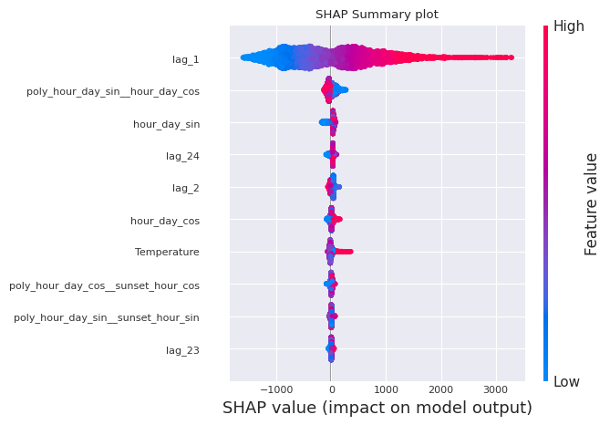

```python
# Shap summary plot (top 10)
# ==============================================================================
shap.summary_plot(shap_values, X_train_sample, max_display=10, show=False)
fig, ax = plt.gcf(), plt.gca()
ax.set_title("SHAP Summary plot")
ax.tick_params(labelsize=8)
fig.set_size_inches(8, 4.5)
```

```python
# Force plot for the first observation
# ==============================================================================
shap.force_plot(explainer.expected_value, shap_values[0,:], X_train_sample.iloc[0,:])
```

## Feature selection

Feature selection is the process of selecting a subset of relevant features for use in model construction. It is an important step in the machine learning process, as it can help to reduce overfitting, improve model accuracy, and reduce training time. Since the underlying regressors of skforecast follow the scikit-learn API, it is possible to apply the [feature selection methods](https://scikit-learn.org/stable/modules/feature_selection.html#feature-selection) available in scikit-learn with the function `select_features()`. Two of the most popular methods are [Recursive Feature Elimination](https://scikit-learn.org/stable/modules/feature_selection.html#recursive-feature-elimination) and [Sequential Feature Selection](https://scikit-learn.org/stable/modules/feature_selection.html#sequential-feature-selection).

**💡 Tip**

Feature selection is a powerful tool for improving the performance of machine learning models. However, it is computationally expensive and can be time-consuming. Since the goal is to find the best subset of features, not the best model, it is not necessary to use the entire data set or a highly complex model. Instead, it is recommended to use a **small subset of the data and a simple model**. Once the best subset of features has been identified, the model can then be trained using the entire dataset and a more complex configuration.  
For example, in this use case, the best model is an `LGMBRegressor` with 800 trees and a maximum depth of 8. However, to find the best subset of features, only 100 trees and a maximum depth of 5 are used.

```python
# Create forecaster
# ==============================================================================
regressor = LGBMRegressor(
                n_estimators = 100,
                max_depth = 5,
                random_state = 15926,
                verbose = -1
            )

forecaster = ForecasterAutoreg(
                 regressor = regressor,
                 lags = 24
             )

# Recursive feature elimination with cross-validation
# ==============================================================================
selector = RFECV(
    estimator              = regressor,
    step                   = 1,
    cv                     = 3,
    min_features_to_select = 25,
    n_jobs                 = -1
)
selected_lags, selected_exog = select_features(
    forecaster      = forecaster,
    selector        = selector,
    y               = data_train['Demand'],
    exog            = data_train[exog_features],
    select_only     = None,
    force_inclusion = None,
    subsample       = 0.5,
    random_state    = 123,
    verbose         = True,
)
```

```
Recursive feature elimination (RFECV)
-------------------------------------
Total number of records available: 17352
Total number of records used for feature selection: 8676
Number of features available: 112
    Autoreg (n=24)
    Exog    (n=88)
Number of features selected: 67
    Autoreg (n=24) : [1, 2, 3, 4, 5, 6, 7, 8, 9, 10, 11, 12, 13, 14, 15, 16, 17, 18, 19, 20, 21, 22, 23, 24]
    Exog    (n=43) : ['week_of_year_sin', 'week_of_year_cos', 'week_day_sin', 'hour_day_sin', 'hour_day_cos', 'poly_month_sin__week_of_year_sin', 'poly_month_sin__week_of_year_cos', 'poly_month_sin__week_day_cos', 'poly_month_sin__hour_day_sin', 'poly_month_sin__hour_day_cos', 'poly_month_cos__hour_…
```

Scikit-learn's `RFECV` starts by training a model on the initial set of features, and obtaining the importance of each feature (through attributes such as `coef_` or `feature_importances_`). Then, in each round, the least important features are iteratively removed, followed by cross-validation to calculate the performance of the model with the remaining features. This process continues until further feature removal doesn't improve or starts to degrade the performance of the model (based on a chosen metric), or the `min_features_to_select` is reached.

The final result is an optimal subset of features that ideally balances model simplicity and predictive power, as determined by the cross-validation process.

The forecaster is trained and re-evaluated using the best subset of features.

```python
# Create a forecaster with the selected features
# ==============================================================================
forecaster = ForecasterAutoreg(
                 regressor = LGBMRegressor(**params),
                 lags      = selected_lags,
             )

# Backtesting model with exogenous variables on test data
# ==============================================================================
metric_lgbm, predictions = backtesting_forecaster(
                               forecaster         = forecaster,
                               y                  = data['Demand'],
                               exog               = data[selected_exog],
                               steps              = 24,
                               metric             = 'mean_absolute_error',
                               initial_train_size = len(data[:end_validation]),
                               refit              = False,
                               n_jobs             = 'auto',
                               verbose            = False,
                               show_progress      = True
                           )
print(f"Backtest error: {metric_lgbm:.2f}")
```

```
Backtest error: 129.00
```

The performance of the model is not compromised. The number of features is reduced from 112 to 67, making the model simpler and faster to train. In addition, the risk of overfitting is reduced because the model is less likely to learn noise from irrelevant features.

## Direct multi-step forecasting

The `ForecasterAutoreg` and `ForecasterAutoregCustom` models follow a [recursive strategy](https://skforecast.org/latest/introduction-forecasting/introduction-forecasting.html#recursive-multi-step-forecasting) in which each new prediction is based on the previous one. Another strategy for multi-step forecasting involves training a separate model for each step to be predicted. This is known as [direct multi-step forecasting](https://skforecast.org/latest/introduction-forecasting/introduction-forecasting.html#direct-multi-step-forecasting) and, although more computationally expensive than the recursive approach due to the need to train multiple models, it may yield better results.

```python
# Forecaster with direct method
# ==============================================================================
forecaster = ForecasterAutoregDirect(
                 regressor        = LGBMRegressor(**params),
                 steps            = 24, # Steps to forecast
                 lags             = selected_lags
             )

# Backtesting model
# ==============================================================================
metric, predictions = backtesting_forecaster(
                          forecaster         = forecaster,
                          y                  = data['Demand'],
                          exog               = data[selected_exog],
                          steps              = 24,
                          metric             = 'mean_absolute_error',
                          initial_train_size = len(data[:end_validation]),
                          refit              = False,
                          n_jobs             = 'auto',
                          verbose            = False,
                          show_progress      = True
                      )

print(f"Backtest error (MAE): {metric:.2f}")
predictions.head()
```

```
Backtest error (MAE): 120.66
```

|  | pred |
| --- | --- |
| 2014-12-01 00:00:00 | 5560.118920 |
| 2014-12-01 01:00:00 | 5643.764926 |
| 2014-12-01 02:00:00 | 5888.027943 |
| 2014-12-01 03:00:00 | 5930.036250 |
| 2014-12-01 04:00:00 | 6197.153056 |

The direct multi-step forecasting model outperforms the predictive capability of the recursive model, further reducing the mean absolute error. However, it is important to keep in mind its higher computational cost in assessing whether it is worth implementing.

## Anticipated daily forecast

So far, we have evaluated the model under the assumption that the forecasts for the next day are generated at exactly 11:59 PM each day. However, this approach is impractical because there is no time to manage the early hours of the next day.

Now, suppose that the predictions for the next day need to be made at 11:00 AM each day to allow enough time. This means that at 11:00 on day $D$ you have to forecast the hours [12, 13, 14, 15, 16, 17, 18, 19, 20, 21, 22, 23] of the same day and the hours [0, 1, 2, 3, 4, 5, 6, 7, 8, 9, 10, 11, 12, 13, 14, 15, 16, 17, 18, 19, 20, 21, 22, 23] of day $D+1$. This means that a total of 36 hours into the future have to be predicted, although only the last 24 hours have to be stored.

This type of evaluation can be easily done using the `backtesting_forecaster()` function and its `gap` argument. In addition, the `allow_incomplete_fold` argument allows the last fold to be excluded from the analysis if it does not have the same size as the required number of steps. The process adapted to this scenario is run on a daily basis and consists of the following steps:

1. At 11:00 a.m. on the first day of the test set, the next 36 hours (the remaining 12 hours of the day plus 24 hours of the following day) are predicted.
2. Only the forecasts for the next day are stored, i.e. starting from position 12.
3. The next day until 11:00 a.m. is added to the test set.
4. The process is repeated.

Thus, at 11:00 a.m. each day, the model has access to the actual demand values recorded up to that time.

[figure not shown]

**⚠ Warning**

There are two considerations to take into account:

- **Training data must end where the gap begins**. In this case, the `initial_train_size` must be extended by 12 positions so that the first point to be predicted is *2014-12-01 12:00:00*.
- In this example, although only the last 24 predictions (steps) are stored for model evaluation, the **total number of predicted steps in each fold is 36** (steps + gap).

```python
# End of initial_train_size + 12 positions
# ==============================================================================
data.iloc[:len(data.loc[:end_validation])+12].tail(2)
```

| Time | Demand | month_sin | month_cos | week_of_year_sin | week_of_year_cos | week_day_sin | week_day_cos | hour_day_sin | hour_day_cos | sunrise_hour_sin | ... | temp_roll_mean_1_day | temp_roll_mean_7_day | temp_roll_max_1_day | temp_roll_min_1_day | temp_roll_max_7_day | temp_roll_min_7_day | holiday_previous_day | holiday_next_day | Temperature | Holiday |
| --- | --- | --- | --- | --- | --- | --- | --- | --- | --- | --- | --- | --- | --- | --- | --- | --- | --- | --- | --- | --- | --- |
| 2014-12-01 10:00:00 | 5084.011230 | -2.449294e-16 | 1.0 | -0.354605 | 0.935016 | 0.781832 | 0.62349 | 2.588190e-01 | -0.965926 | 0.965926 | ... | 25.589582 | 18.573214 | 30.950001 | 20.0 | 33.849998 | 11.15 | 0.0 | 0.0 | 19.90 | 0.0 |
| 2014-12-01 11:00:00 | 4851.066895 | -2.449294e-16 | 1.0 | -0.354605 | 0.935016 | 0.781832 | 0.62349 | 1.224647e-16 | -1.000000 | 0.965926 | ... | 25.129168 | 18.601191 | 29.500000 | 19.9 | 33.849998 | 11.15 | 0.0 | 0.0 | 19.35 | 0.0 |

2 rows × 89 columns

```python
# Backtesting with gap
# ==============================================================================
forecaster = ForecasterAutoreg(
                 regressor = LGBMRegressor(**params),
                 lags      = selected_lags,
             )

metric, predictions = backtesting_forecaster(
                          forecaster            = forecaster,
                          y                     = data['Demand'],
                          exog                  = data[selected_exog],
                          steps                 = 24,
                          metric                = 'mean_absolute_error',
                          initial_train_size    = len(data.loc[:end_validation])+12,
                          gap                   = 12, # Number of positions to skip
                          allow_incomplete_fold = True,
                          refit                 = False,
                          n_jobs                = 'auto',
                          verbose               = False,
                          show_progress         = True
                      )

print("")
print(f"Backtest error (MAE): {metric:.2f}")
predictions.head(5)
```

```
Backtest error (MAE): 158.14
```

|  | pred |
| --- | --- |
| 2014-12-02 00:00:00 | 5457.045473 |
| 2014-12-02 01:00:00 | 5534.191363 |
| 2014-12-02 02:00:00 | 5665.586279 |
| 2014-12-02 03:00:00 | 5797.378587 |
| 2014-12-02 04:00:00 | 5958.440195 |

As expected, the error increases as the forecast horizon increases from 24 to 36 hours.

## Conclusions

The use of gradient boosting models has proven to be a powerful tool for forecasting energy demand. One of the main advantages of these models is that they can easily incorporate exogenous variables, which can significantly improve the predictive power of the model. In addition, the use of explicability techniques can help to visually and quantitatively understand how variables and values affect predictions. All of these issues are easily addressed using the skforecast library.

| Forecaster | Exogenous Variables | MAE backtest |
| --- | --- | --- |
| `ForecasterEquivalentDate` (Baseline) | False | 308.4 |
| `ForecasterAutoreg` | False | 198.3 |
| `ForecasterAutoreg` | True | 129.8 |
| `ForecasterAutoreg` | True (Feature Selection) | 129.0 |
| `ForecasterAutoregDirect` | True (Feature Selection) | 120.7 |

## Session information

```python
import session_info
session_info.show(html=False)
```

```
-----
astral              3.2
lightgbm            4.3.0
matplotlib          3.8.4
numpy               1.26.4
optuna              3.4.0
pandas              2.1.4
plotly              5.21.0
session_info        1.0.0
shap                0.45.0
skforecast          0.12.0
sklearn             1.3.2
statsmodels         0.14.1
-----
IPython             8.22.2
jupyter_client      8.6.1
jupyter_core        5.7.2
notebook            6.4.12
-----
Python 3.11.8 (main, Feb 26 2024, 21:39:34) [GCC 11.2.0]
Linux-5.15.0-1058-aws-x86_64-with-glibc2.31
-----
Session information updated at 2024-05-05 15:04
```

## Bibliography

Hyndman, R.J., & Athanasopoulos, G. (2021) Forecasting: principles and practice, 3rd edition, OTexts: Melbourne, Australia.

Time Series Analysis and Forecasting with ADAM Ivan Svetunkov

Joseph, M. (2022). Modern time series forecasting with Python: Explore industry-ready time series forecasting using modern machine learning and Deep Learning. Packt Publishing.

## Citation

**How to cite this document**

If you use this document or any part of it, please acknowledge the source, thank you!

Forecasting energy demand with machine learning by Joaquín Amat Rodrigo and Javier Escobar Ortiz, available under Attribution-NonCommercial-ShareAlike 4.0 International (CC BY-NC-SA 4.0 DEED) at https://www.cienciadedatos.net/documentos/py29-forecasting-electricity-power-demand-python.html

**How to cite skforecast**

If you use skforecast for a scientific publication, we would appreciate it if you cite the published software.

Zenodo:

Amat Rodrigo, Joaquin, & Escobar Ortiz, Javier. (2023). skforecast (v0.12.0). Zenodo. https://doi.org/10.5281/zenodo.8382788

APA:

Amat Rodrigo, J., & Escobar Ortiz, J. (2023). skforecast (Version 0.12.0) [Computer software]. https://doi.org/10.5281/zenodo.8382788

BibTeX:

@software{skforecast, author = {Amat Rodrigo, Joaquin and Escobar Ortiz, Javier}, title = {skforecast}, version = {0.12.0}, month = {2}, year = {2024}, license = {BSD-3-Clause}, url = {https://skforecast.org/}, doi = {10.5281/zenodo.8382788} }

**Did you like the article? Your support is important**

Website maintenance has high cost, your contribution will help me to continue generating free educational content. Many thanks! 😊

This work by Joaquín Amat Rodrigo and Javier Escobar Ortiz is licensed under a [Attribution-NonCommercial-ShareAlike 4.0 International](https://creativecommons.org/licenses/by-nc-sa/4.0/).